# Final_version_report

Guanghao He

3/12/2022

# I. Abstract

With the prevalence of COVID-19 and the arriving of vaccine, COVID-19 seems disappear gradually. However, we care more about the relationship between the cumulative death case, the number of vaccines received for different WHO regions. If there is no big area difference, the relationship between the number of vaccine types and the cumulative death case. We try to base on our data and model to answer our interest. Based on our model, we find that there isn’t big difference between different WHO regions. Also, we can conclude that even with the increment of vaccine recieved, the cumulative death case for a country still increase, although our model fit well. This report consists of 6 main parts: Introduction,Background, Method, Model Fit, Model diagnostics/ sensitivity analysis and Conclusion.

# II. Introduction

We are going to explore the influence towards the number of cumulative confirmed deaths reported to date (02/17/2022) of six levels of the factor different geographical regions of WHO regional offices(AFRO, AMRO, EMRO, EURO, SEARO, WPRO) and 10 levels of another factor types of used vaccine. Or to say specifically, why there exist the abnormal situation that more types of vaccines used, more cumulative deaths in different regions. As some regions and certain types of vaccine exists few sample and abnormal measurements, our final chosen factors are geographical regions with 4 levels (“AFRO”, “AMRO,”EURO“,”WPRO“) and the number of vaccine types used with 7 levels (”1“,”2“…”7"). We use two data sets from [WHO Database](https://covid19.who.int/info). The first data file named daily cases and deaths by date reported to WHO and another is called Vaccination data. Our main data sets are published on the WHO website. The benefit of this public resource is that most data are clean and ready to be used. The shortcoming is that the WHO website doesn’t provide more detailed information about the specific case. We can only learn the whole trend for different countries and different areas. Thus, we realize that the difference between areas plays an important role in spreading Covid and also due to the importance of vaccination to confirmed death cases. With the arrival of vaccination, more people get immunity to Covid. We decide to use two datasets: who-covid-19-global-data and vaccination data. Based on those two data sets, we can learn the updated cumulative confirmed case for different areas, vaccination receiving information. Because of the setting of our problem, we care more about the relationship between the cumulative death case, the number of vaccines received for different WHO regions. In our experiment, we assume there is no obvious difference between vaccines due to the lack of more specific information.

# III. Background

# IV. Method

## 1. Data cleaning and processing

The first step is to filter our data to the newest date because the number of confirmed cases and the number of vaccines received are cumulative. We only need to keep track of the newest update. The second step is to merge two datasets into one based on country. For each country, we will have the number of vaccines received, the cumulative confirmed cases, and belonging WHO regions. Finally, we remove all missing values because some countries lack death data. The reason for missing value is that some countries don’t have too many citizens, which means these countries should be considered as extreme values. To make sure the accuracy of our future model, we simply remove those outliers. There is only three missing value for the number of vaccines types used, which doesn’t influence the big picture.

Important variables description are shown in below chart.

| column names | explanation |
| --- | --- |
| WHO_region | The WHO divided the world into six region |
| NUMBER_VACCINES_TYPES_USED | The number of vaccines used |
| Cumulative_deaths | The number of cumulative COVID-19 deaths |

## 2. Exploratory data analysis.

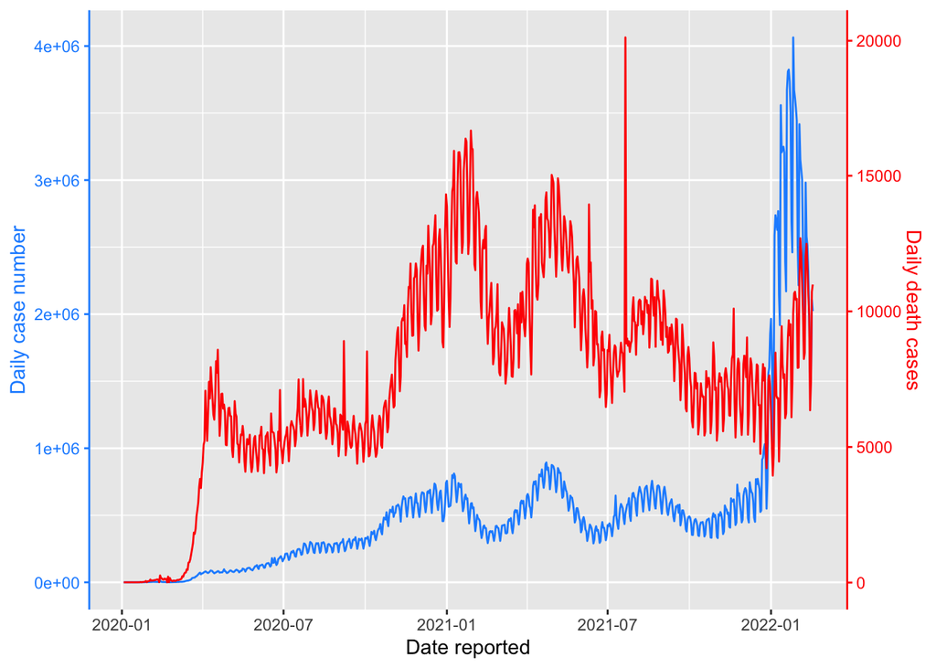

Figure 1. The time series plot for daily new COVID-19 case number and daily new COVID-19 death case

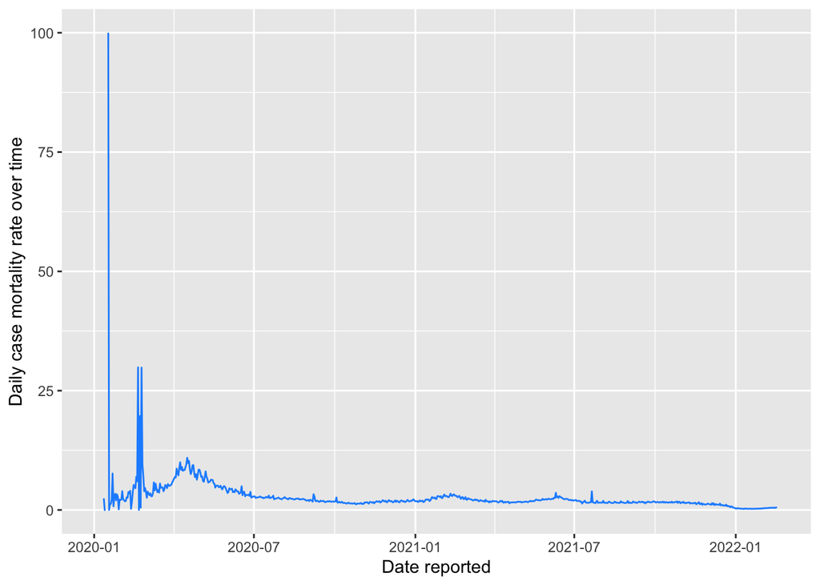

Figure 2. The case mortality rate over time aggregated all countries

The first step for our analysis is to summary all related variables. We combine two data set based on the country. Below is the result of summary statistics of data set merged by original two data sets. There are 223 observation in total with 19 columns. This is not our final data sets because of the existence of missing values. From below summary, we could find the basic statistics summary of each column like mean, maximum, standard deviation and etc. Also, the histogram of each column is attached in the following table. To be notice, to answer our interest, we should consider removing the missing values and 0. At this part, we don’t specific this process.

Data summary

| Name | data_3 |
| --- | --- |
| Number of rows | 223 |
| Number of columns | 19 |
| _______________________ |  |
| Column type frequency: |  |
| character | 8 |
| numeric | 11 |
| ________________________ |  |
| Group variables | None |

**Variable type: character**

| skim_variable | n_missing | complete_rate | min | max | empty | n_unique | whitespace |
| --- | --- | --- | --- | --- | --- | --- | --- |
| Country | 0 | 1 | 4 | 46 | 0 | 223 | 0 |
| Date_reported | 0 | 1 | 10 | 10 | 0 | 1 | 0 |
| Country_code | 1 | 1 | 2 | 2 | 0 | 222 | 0 |
| WHO_region | 0 | 1 | 4 | 5 | 0 | 6 | 0 |
| DATA_SOURCE | 0 | 1 | 4 | 9 | 0 | 2 | 0 |
| DATE_UPDATED | 0 | 1 | 8 | 10 | 0 | 43 | 0 |
| VACCINES_USED | 0 | 1 | 0 | 244 | 3 | 117 | 0 |
| FIRST_VACCINE_DATE | 0 | 1 | 0 | 10 | 19 | 102 | 0 |

**Variable type: numeric**

| skim_variable | n_missing | complete_rate | mean | sd | p0 | p25 | p50 | p75 | p100 | hist |
| --- | --- | --- | --- | --- | --- | --- | --- | --- | --- | --- |
| New_cases | 0 | 1.00 | 9056.81 | 27079.22 | 0.00 | 0.00 | 135.00 | 3892.50 | 2.356260e+05 | ▇▁▁▁▁ |
| Cumulative_cases | 0 | 1.00 | 1862287.82 | 6704491.03 | 0.00 | 17735.00 | 147786.00 | 974535.50 | 7.741318e+07 | ▇▁▁▁▁ |
| New_deaths | 0 | 1.00 | 49.19 | 222.69 | 0.00 | 0.00 | 1.00 | 19.00 | 2.938000e+03 | ▇▁▁▁▁ |
| Cumulative_deaths | 0 | 1.00 | 26159.52 | 91453.56 | 0.00 | 155.50 | 1915.00 | 12220.00 | 9.185600e+05 | ▇▁▁▁▁ |
| TOTAL_VACCINATIONS | 0 | 1.00 | 46034755.95 | 238441195.96 | 74.00 | 346581.00 | 2515341.00 | 15767357.00 | 3.016699e+09 | ▇▁▁▁▁ |
| PERSONS_VACCINATED_1PLUS_DOSE | 3 | 0.99 | 21993672.14 | 110310021.50 | 37.00 | 174550.50 | 1396101.00 | 7562514.75 | 1.275814e+09 | ▇▁▁▁▁ |
| TOTAL_VACCINATIONS_PER100 | 0 | 1.00 | 118.92 | 70.72 | 0.09 | 62.16 | 122.91 | 173.40 | 3.328400e+02 | ▇▇▇▃▁ |
| PERSONS_VACCINATED_1PLUS_DOSE_PER100 | 3 | 0.99 | 54.69 | 27.22 | 0.07 | 33.94 | 62.39 | 76.09 | 1.237100e+02 | ▅▅▇▇▁ |
| PERSONS_FULLY_VACCINATED | 3 | 0.99 | 19291631.30 | 99948614.84 | 37.00 | 148557.50 | 1104662.00 | 6330172.50 | 1.235248e+09 | ▇▁▁▁▁ |
| PERSONS_FULLY_VACCINATED_PER100 | 3 | 0.99 | 49.02 | 26.50 | 0.07 | 28.26 | 53.12 | 71.44 | 1.210100e+02 | ▅▅▇▅▁ |
| NUMBER_VACCINES_TYPES_USED | 3 | 0.99 | 3.93 | 1.92 | 1.00 | 2.75 | 4.00 | 5.00 | 1.100000e+01 | ▇▇▃▁▁ |

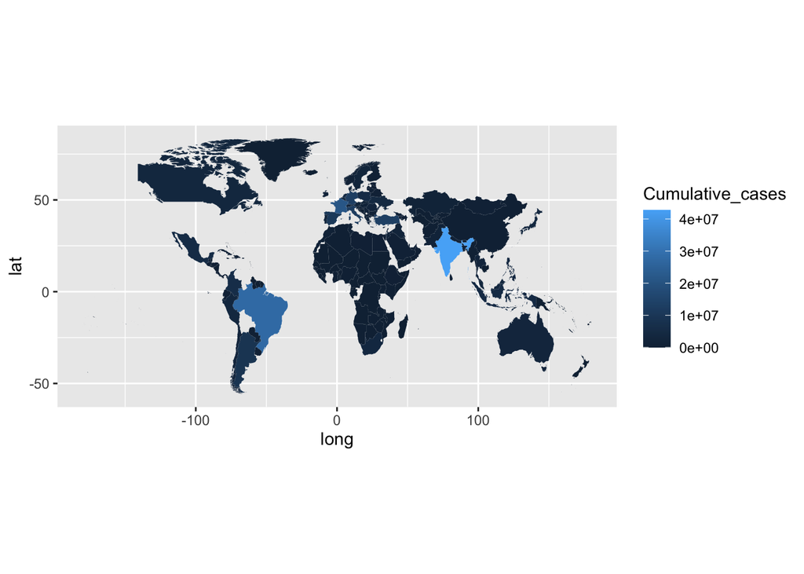

Third step is to filter our target data sets that satisfy our needs. So, we only keep three columns: WHO_region, NUMBER_VACCINES_TYPES_USED and Cumulative_deaths. The detail explanation for each variables is shown in previous section. The missing value and abnormal measurement for number of vaccine type used is 3. The specific reason why we remove those missing values are explained in data cleaning parts.

Data summary

| Name | data |
| --- | --- |
| Number of rows | 223 |
| Number of columns | 3 |
| _______________________ |  |
| Column type frequency: |  |
| character | 1 |
| numeric | 2 |
| ________________________ |  |
| Group variables | None |

**Variable type: character**

| skim_variable | n_missing | complete_rate | min | max | empty | n_unique | whitespace |
| --- | --- | --- | --- | --- | --- | --- | --- |
| WHO_region | 0 | 1 | 4 | 5 | 0 | 6 | 0 |

**Variable type: numeric**

| skim_variable | n_missing | complete_rate | mean | sd | p0 | p25 | p50 | p75 | p100 | hist |
| --- | --- | --- | --- | --- | --- | --- | --- | --- | --- | --- |
| NUMBER_VACCINES_TYPES_USED | 3 | 0.99 | 3.93 | 1.92 | 1 | 2.75 | 4 | 5.0 | 11 | ▇▇▃▁▁ |
| Cumulative_deaths | 16 | 0.93 | 28181.52 | 94636.70 | 2 | 290.00 | 2524 | 14621.5 | 918560 | ▇▁▁▁▁ |

Here we shows the frequency table to show the reason why we shouldn’t to use Two-way ANOVA model as our model candidate. There exists 0 observation in certain level of two factors, which is discrete or like counts and hence two-way ANOVA may not be a good choice. The generalized linear mixed models is much more fitful model in theoretical analysis.

Generate frequency tables:

```
##
##          1  2  3  4  5  6  7  8  9 11
##   AFRO   9 12 11  8  3  2  1  0  0  0
##   AMRO   5  8  9  5 10  7  2  1  1  0
##   EMRO   0  0  1  6  5  5  2  2  0  0
##   EURO   3  5  9 30  5  5  3  0  0  0
##   SEARO  0  1  0  1  1  2  2  3  0  0
##   WPRO   6  6  7  6  3  2  1  3  0  1
```

The left frequency table is shown below. We observe there doesn’t 0 in our data set, which stratify our need for model selection and the quality of choose levels of two factors are better.

```
##
##         1  2  3  4  5  6  7
##   AFRO  9 12 11  8  3  2  1
##   AMRO  5  8  9  5 10  7  2
##   EURO  3  5  9 30  5  5  3
##   WPRO  6  6  7  6  3  2  1
```

Now, we explore our response variable’s distribution. We use the Box-Cox transformation to apply remedy way of asymmetry of a variable, different variances or non linearity between variables. When there appears to be unequal variance or/and non-normality problems, transformation should be done on the response variable Y. Below is the result of Box-cox transformation. From this figure, we find that the 0 is inside the 95% confidence interval of the optimal λ and as the estimation of the parameter is really close to 0, the best option is to apply the logarithmic transformation of the data.

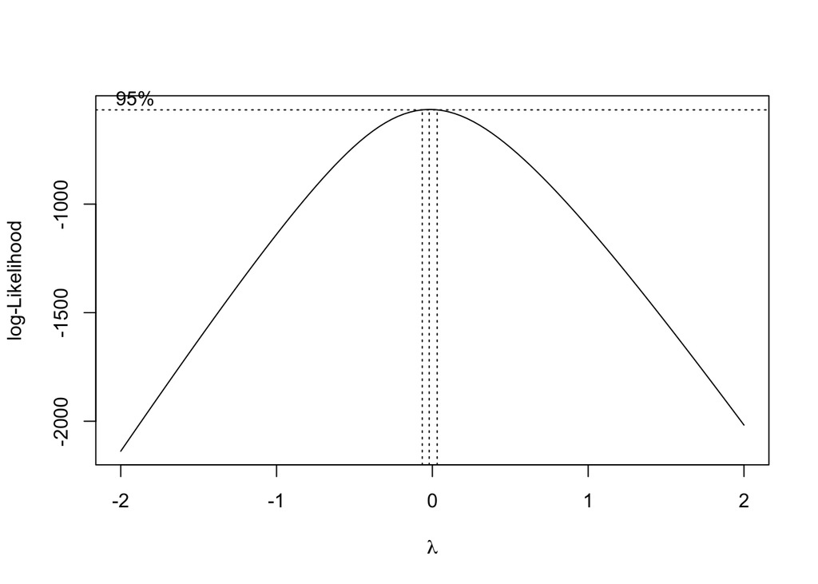

Figure 4. The Boxcox plot of response variable

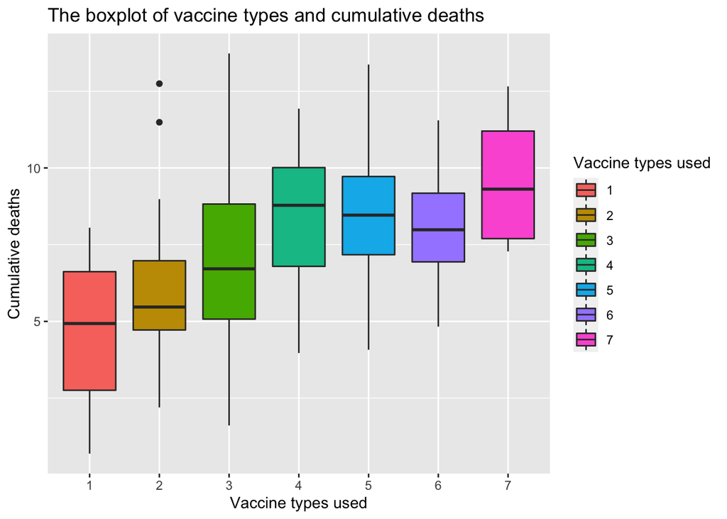

Figure 5. The boxplot of number of vaccine used vs the log(Cumulative death case)

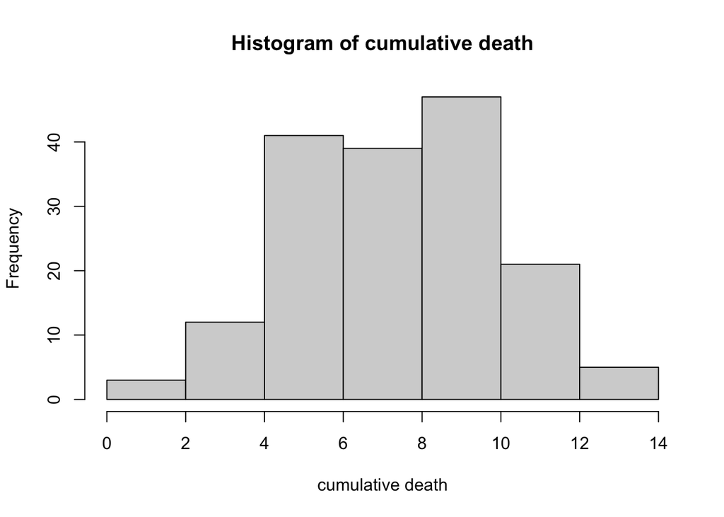

Below the pairwise scatter plot, we could see there is no obvious relationship between our three variables.

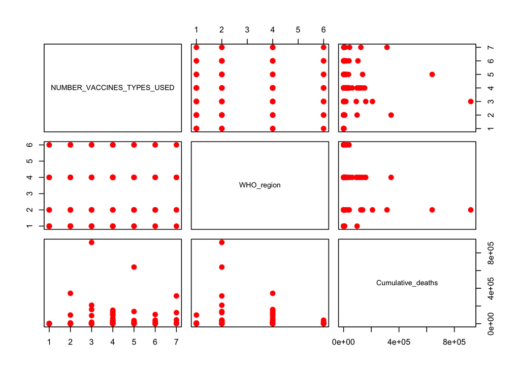

Figure 7. The pairwise scatter plot among three variables.

Before fitting the model, we would like to investigate whether there is linear relationship between depedent variables and indepedent variables by drawing the scatter plot. As we mentioned before, it is important to take log transformation of origianl variables.

Below is the scatter plot of the number of vaccine used and cumulative deaths. Most region have the trend is almost the same, pointing to top-right. To be notice, the number of cumulative death is log transformation. At this point, we have a sense to use multi-level models (or GLM)

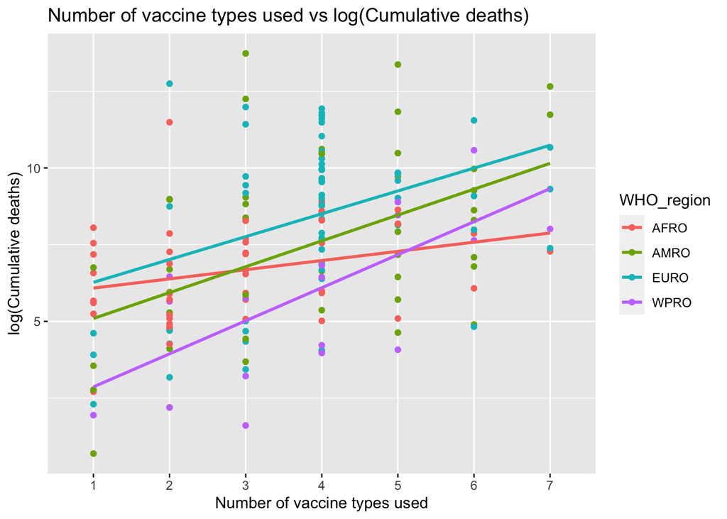

Figure 8. The Scatter plot of number of vaccine used vs the log(Cumulative death case)

## 3. Model Selection

Then, we want to estimate the necessary parameters to describe the assumed error distribution. The following part is used for selecting error distribution candidate. The Cullen and Frey Graph below is a good way to exempt some distributions by the parameters of skewness and kurtosis using the descdist function. We find that our observation (blue point) seems belong to normal,beta and Weibull distribution. It’s worth noting that all cumulative deaths cases is log transformation.

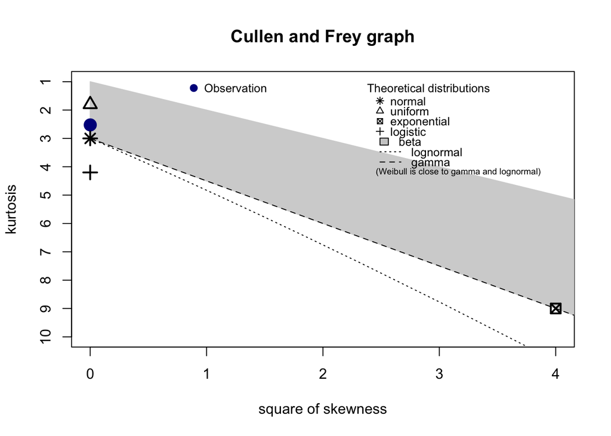

Figure 8. The Cullen and Frey graph for log(Cumulative death case)

```
## summary statistics
## ------
## min:  0.6931472   max:  13.73056
## median:  7.553278
## mean:  7.42126
## estimated sd:  2.658913
## estimated skewness:  -0.02369806
## estimated kurtosis:  2.523734
```

|  | AIC value |
| --- | --- |
| beta distribution | -48.6408744201937 |
| weibull distribution | 807.422334954955 |
| normal distribution | 808.34064065556 |

# V. Model Fit

## 1. Final selection

Current stage, we have three candidates: linear mixed-effect model with normal distribution response, generalized linear model with beta distribution response and generalized linear mixed model with beta distribution response.

The final model that we choose is the generalized linear model with beta distribution response. The final model is shown below.

```r
GLM_2 <- glmmTMB(abs(range01(log(Cumulative_deaths)))~ NUMBER_VACCINES_TYPES_USED,family=beta_family(link="logit"), data=data_chs)
```

And to see the below chart, all variables are significant at alpha = 0.05 level and the value is round to two digits.

|  | Estimate | Pr(>\|z\|) |
| --- | --- | --- |
| Intercept | -1.03 | 0 |
| NUMBER_VACCINES_TYPES_USED2 | 0.69 | 0.006 |
| NUMBER_VACCINES_TYPES_USED3 | 1.04 | 0 |
| NUMBER_VACCINES_TYPES_USED4 | 1.35 | 0 |
| NUMBER_VACCINES_TYPES_USED5 | 1.37 | 0 |
| NUMBER_VACCINES_TYPES_USED6 | 1.24 | 0 |
| NUMBER_VACCINES_TYPES_USED7 | 1.73 | 0 |

|  | AIC | BIC |
| --- | --- | --- |
| Simple linear model | 775.08 | 800.08 |
| generalized linear model | -83.02 | -58.03 |

## 2. Model Notation

Thus, this model means that compared with countries with only 1 type of vaccine, other countries have different rate of death increasment. This can be explained opposite with our common senese, which although the types of vaccine increase, the death number still increase. Because those countries only get only 1 or 2 types of vaccince are developing countries which have less citizens than developed countries. The prevelance of COVID-19, unfortunatl, doesn’t stop by the increase of vaccine type. It still meet with parts of our common sense. It can be explained by the degree of development of countries, developed countries have more medical resource and more citizens, which still lead to the large number of death because of large infected number.

## 3. Model assumption

Our model has assumptions from below aspects: 1. The data are independently distributed 2. A GLM does NOT assume a linear relationship between the response variable and the explanatory variables, but it does assume a linear relationship between the transformed expected response in terms of the link function and the explanatory variables. 3.The homogeneity of variance does NOT need to be satisfied.

Under our model, no assumptions are violated. From our finding distribution process, we find our response variable have beta distribution. After the log transformation, we find that there is a linear relationship between the transformed expected response and the independent variables. Moreover, our residual plots show the normal distribution of our residual. Thus, there is no specific assumption violated for our model.

# VI. Model diagnostics and sensitivity analysis

## 1. Deviance Residuals and Pearson Residuals

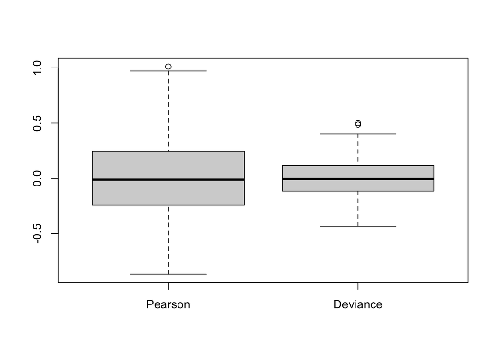

Figure 9 The residual distribution of residuals

## 2. Residual Plots

The quantile plot (also called a normal probability plot) does not raise any significant concern with normality of the weighted residuals.

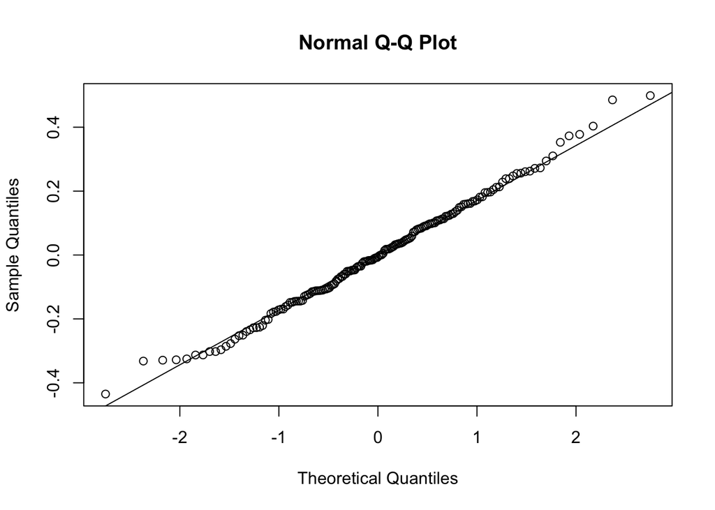

Figure 10 normal qq plot for final model

The plot of residuals against ftted values seems randomly distributed around 0, which does not raise any significant concern to our goodness- fit.

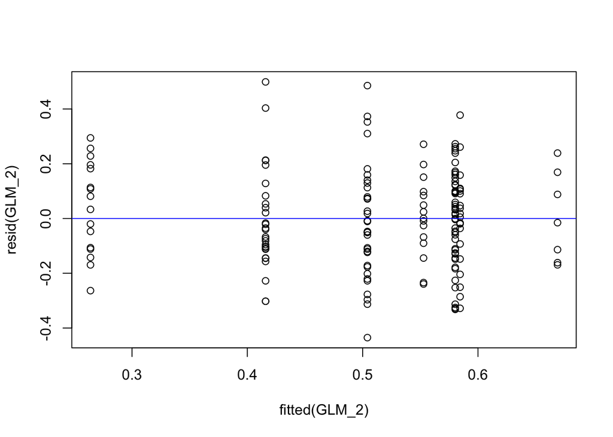

Figure 11 residuals against fitted values

## 3. Runs Test

Below is the result of runs test. The null hypothesis of runs test that there are no systematic patterns in a sequence of random numbers, here the residuals.Any systematic trend (no matter positive/negative correlated) suffices to reject the goodness-of-fit of the model. Here our p-value is large enough which fail to reject the null hypothesis. This means our model has goodness-of-fit.

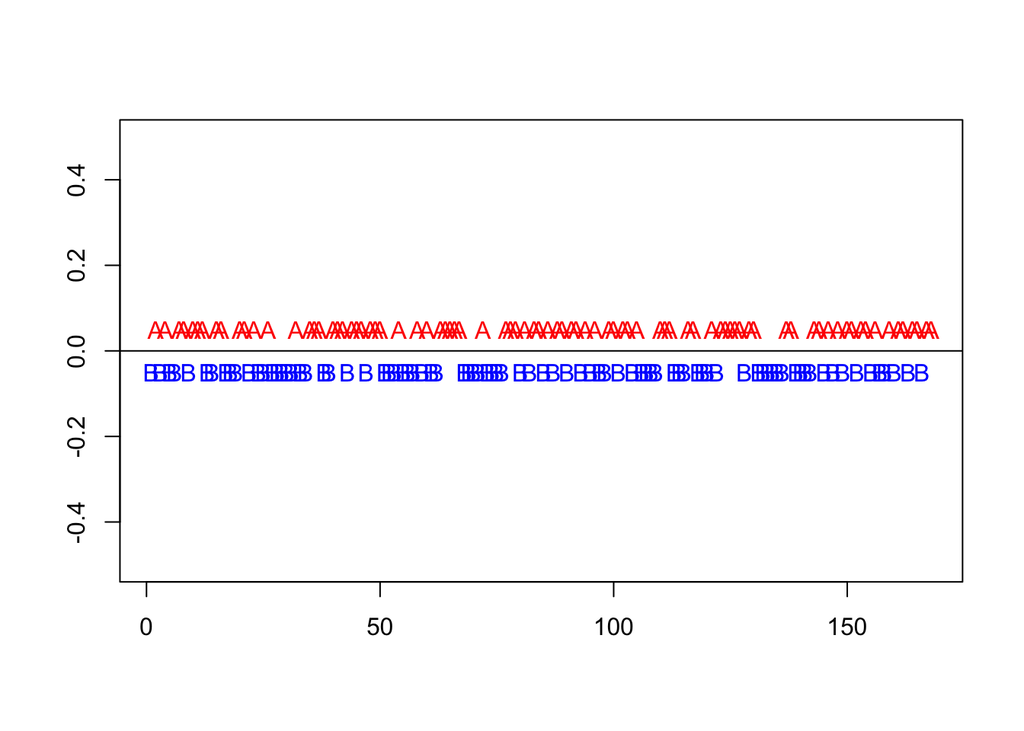

```
##
##  Runs Test - Two sided
##
## data:  res.D
## Standardized Runs Statistic = 0.77384, p-value = 0.439
```

# VII. Conclusion

Based on our model and our analysis, unfortunately, the cumulative death for countries doesn’t decrease with the increase of vaccine type. Also, since we exclude the area difference of WHO regions,this is opposite with our commmon sense. However, it still meet with parts of our common sense. It can be explained by the degree of development of countries, developed countries have more medical resource and more citizens, which still lead to the large number of death because of large infected number. Although our model fit the data well without violating any assumptions. From the beginning EDA part, we find that it is impossible to answer our interest by two-way ANOVA. Then, we based on three model candidates based on two aspects to choose the best model for our data, which is the generalized linear model with beta distribution response. One is due to the failure of randome effect. Another one is due to the link function. Last step is to do model diagnostics and test for the assumption. Our model fit our data very without violating any assumption.

# Data Source

1. Data_1 https://covid19.who.int/WHO-COVID-19-global-data.csv

2.Data_2 https://covid19.who.int/who-data/vaccination-data.csv

# APPENDIX

## 1. Check for response variable’s distribution

### a. normal distribution

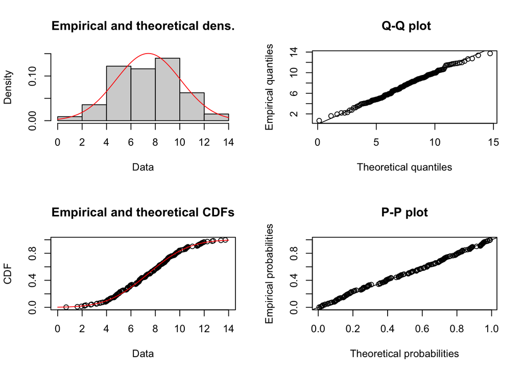

### b. beta distribution

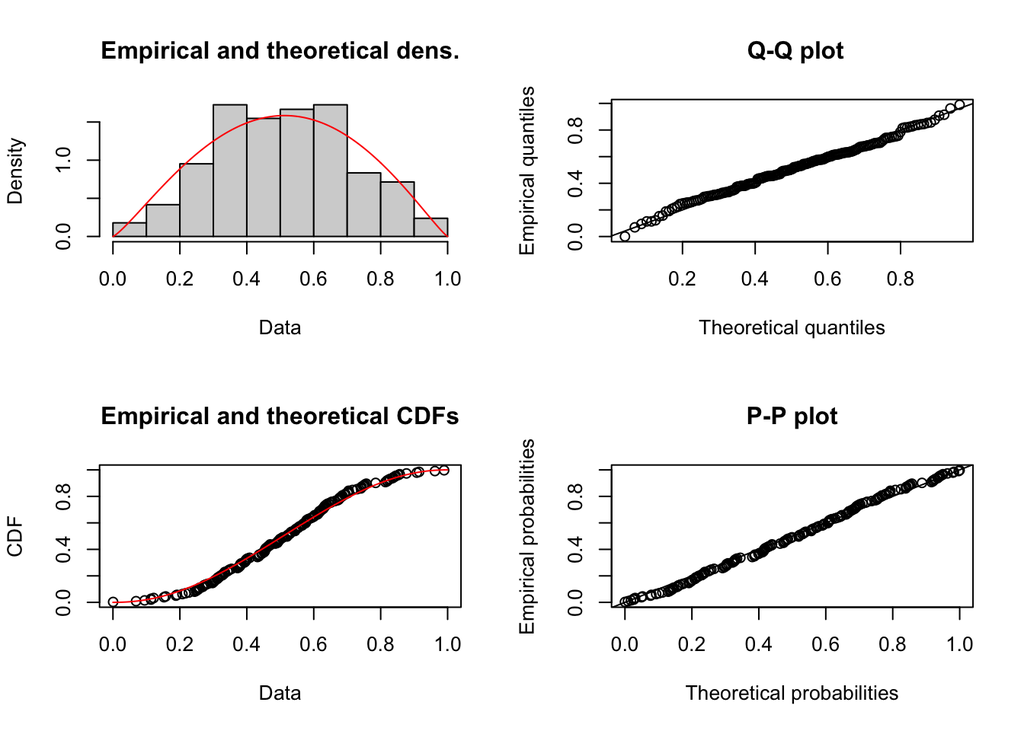

### c. Weibull distribution

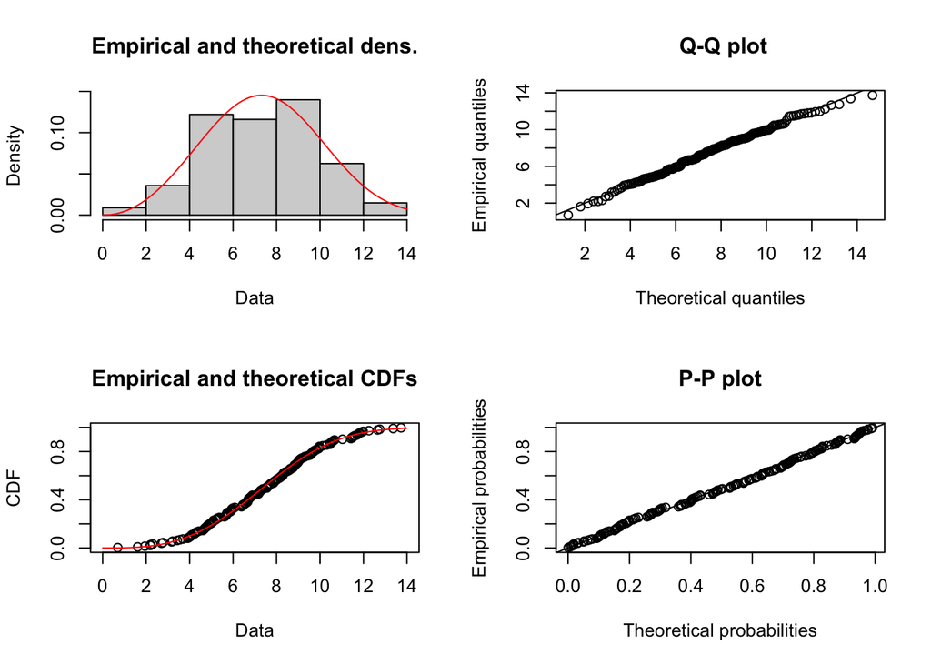

# Code attached

```r
# import two data set and load all useful packages
data_1 <- read.csv("~/Desktop/207/WHO-COVID-19-global-data.csv")
data_2 <- read.csv("~/Desktop/207/vaccination-data.csv")
library(dplyr)
library(lme4)
require(car)
require(MASS)
library(car)
library(ggplot2)
library(fitdistrplus)
library(logspline)
library(maps)
library(scales)
library(skimr)
library(snpar)
library(DHARMa)
library(glmmTMB)
library(boot)
library(htmlTable)
library(magrittr)
library(lawstat)
daily_case <- data_1 %>%
  group_by(Date_reported) %>%
  mutate(daily_case = sum(New_cases),
         daily_death = sum(New_deaths)) %>%
  mutate(case_mortaility = daily_death*100/daily_case) %>%
  distinct(Date_reported,daily_case,daily_death,case_mortaility)
scale_value = max(daily_case$daily_case, na.rm = TRUE)/ max(daily_case$daily_death, na.rm = TRUE)
ggplot(daily_case) %>% +
  geom_line(aes(x=as.Date(Date_reported), y=daily_case), color = 'dodgerblue') +
  geom_line(aes(x=as.Date(Date_reported), y=daily_death*scale_value),color ='red') +
  scale_y_continuous(sec.axis = sec_axis(~./scale_value, name = 'Daily death cases')) +
  xlab('Date reported') +
  ylab('Daily case number') +
  theme(axis.line.y.right = element_line(color = "red"),
        axis.ticks.y.right = element_line(color = "red"),
        axis.text.y.right = element_text(color = "red"),
        axis.title.y.right = element_text(color = "red"),
        axis.line.y.left = element_line(color = "dodgerblue"),
        axis.ticks.y.left  = element_line(color = "dodgerblue"),
        axis.text.y.left = element_text(color = "dodgerblue"),
        axis.title.y.left = element_text(color = "dodgerblue")
        )
ggplot(daily_case)+
  geom_line(aes(x=as.Date(Date_reported), y=case_mortaility), color = 'dodgerblue') +
  xlab('Date reported') +
  ylab('Daily case mortality rate over time')

data_1 <- data_1 %>% filter(data_1$Date_reported == '2022-02-17')
colnames(data_2)[colnames(data_2)=="COUNTRY"] <- "Country"
data_3 <- merge(data_1,data_2,by.x="Country") %>%  dplyr::select(-c(ISO3,WHO_REGION))
# colnames(data_3)[colnames(data_3)=="锘緿ate_reported"] <- "Date_reported"
skim(data_3)
world <- map_data("world")
worldplot <- ggplot() +
  geom_polygon(data = world, aes(x=long, y = lat, group = group))

covid.today<- data_3 %>%
  filter(Date_reported == "2022-02-17") %>%
  mutate(region=Country)

covid.today.world<- inner_join(world, covid.today, by = "region")

ggplot() +
  geom_polygon(data = covid.today.world) +
  aes(x=long, y = lat, group = group,fill=Cumulative_cases) +
  coord_fixed(1.3)
data <- data_3 %>% dplyr::select(c(WHO_region,NUMBER_VACCINES_TYPES_USED,Cumulative_deaths))
data[data==0] <- NA
skim(data)
data$WHO_region <- as.factor(data$WHO_region)
data$NUMBER_VACCINES_TYPES_USED <- as.factor(data$NUMBER_VACCINES_TYPES_USED)
table(data$WHO_region,data$NUMBER_VACCINES_TYPES_USED)
target <- c("AFRO","AMRO","EURO","WPRO")
data_chs <-  data %>% filter(WHO_region%in% target)
# table(as.character(data_chs$WHO_region),data_chs$NUMBER_VACCINES_TYPES_USED)
target <- c("1","2","3","4","5","6","7")
data_chs <- data_chs %>% filter(NUMBER_VACCINES_TYPES_USED %in% target)
table(as.character(data_chs$WHO_region),as.character(data_chs$NUMBER_VACCINES_TYPES_USED))
data_chs <- na.omit(data_chs)
boxcox(data_chs$Cumulative_deaths~data_chs$WHO_region+data_chs$NUMBER_VACCINES_TYPES_USED)
ggplot(data_chs %>% filter(!is.na(NUMBER_VACCINES_TYPES_USED)), aes(x=factor(NUMBER_VACCINES_TYPES_USED),fill = as.factor(NUMBER_VACCINES_TYPES_USED), y = log( Cumulative_deaths))) +
  geom_boxplot()+
  labs(fill = "Vaccine types used",
       x= "Vaccine types used",
       y= "Cumulative deaths",
       title= "The boxplot of vaccine types and cumulative deaths")
hist(log(data_chs$Cumulative_deaths),main="Histogram of cumulative death", xlab="cumulative death")
pairs(data_chs%>% ungroup() %>%dplyr::select(NUMBER_VACCINES_TYPES_USED,WHO_region,Cumulative_deaths),pch=16,col='red',cex=1.5)
ggplot(data_chs) +
  aes(y = log(Cumulative_deaths),
      x = NUMBER_VACCINES_TYPES_USED,
      colour = WHO_region,
      group = as.factor(WHO_region)) +
  geom_point() +
  geom_smooth(aes(color = as.factor(WHO_region)),method = "lm", se=FALSE, fullrange=TRUE) +
  labs(title = "Number of vaccine types used vs log(Cumulative deaths)",
       x="Number of vaccine types used",
       y="log(Cumulative deaths)",
       fill= 'WHO region')
descdist(log(data_chs$Cumulative_deaths), discrete = F)
fit.norm <- fitdist(log(data_chs$Cumulative_deaths), "norm")
range01 <- function(x){(x-min(x)*1.01)/(max(x)*1.01-min(x)*1.01)}
fit.beta <- fitdist(abs(range01(log(data_chs$Cumulative_deaths))), "beta")
fit.weibull <- fitdist(log(data_chs$Cumulative_deaths), "weibull")
matrix(c(fit.beta$aic,fit.weibull$aic,fit.norm$aic),
       ncol = 1,
       dimnames = list(c("beta distribution", "weibull distribution","normal distribution"),c("AIC value"))) %>%
  htmlTable
GLM_2 <- glmmTMB(abs(range01(log(Cumulative_deaths)))~ NUMBER_VACCINES_TYPES_USED,family=beta_family(link="logit"), data=data_chs)
matrix(c(round(summary(GLM_2)[["coefficients"]][["cond"]][,1],2),round(summary(GLM_2)[["coefficients"]][["cond"]][,4],3)),
       ncol = 2,
       dimnames = list(c("Intercept","NUMBER_VACCINES_TYPES_USED2","NUMBER_VACCINES_TYPES_USED3","NUMBER_VACCINES_TYPES_USED4","NUMBER_VACCINES_TYPES_USED5","NUMBER_VACCINES_TYPES_USED6","NUMBER_VACCINES_TYPES_USED7"),
                       c("Estimate","Pr(>|z|)")))%>%
  htmlTable
# linear mixed model
lmm <- lmer(log(Cumulative_deaths)~ NUMBER_VACCINES_TYPES_USED + (1 | WHO_region), data = data_chs, REML = T)
lmm_2 <- lm(log(Cumulative_deaths)~ NUMBER_VACCINES_TYPES_USED, data = data_chs)
# generalized linear mixed model with beta distribution response
GLM <- glmmTMB(abs(range01(log(Cumulative_deaths)))~ NUMBER_VACCINES_TYPES_USED + (1 | WHO_region),family=beta_family(link="logit"), data=data_chs)
matrix(c(round(AIC(lmm_2),2),round(AIC(GLM_2),2),round(BIC(lmm_2),2),round(BIC(GLM_2),2)),
       ncol = 2,
       dimnames = list(c("Simple linear model","generalized linear model"),
                       c("AIC","BIC")))%>%
  htmlTable
res.P = residuals(GLM_2, type="pearson")
res.D = residuals(GLM_2)
boxplot(cbind(res.P, res.D), names = c("Pearson", "Deviance"))
qqnorm(resid(GLM_2))
qqline(resid(GLM_2))
plot(fitted(GLM_2),resid(GLM_2))
abline(h=0, col="blue")
runs.test(y = res.D, plot.it = TRUE)
plot(fit.norm)
plot(fit.beta)
plot(fit.weibull)
# linear mixed model
lmm <- lmer(log(Cumulative_deaths)~ NUMBER_VACCINES_TYPES_USED + (1 | WHO_region), data = data_chs, REML = T)
lmm_2 <- lm(log(Cumulative_deaths)~ NUMBER_VACCINES_TYPES_USED, data = data_chs)
# generalized linear mixed model with beta distribution response
GLM <- glmmTMB(abs(range01(log(Cumulative_deaths)))~ NUMBER_VACCINES_TYPES_USED + (1 | WHO_region),family=beta_family(link="logit"), data=data_chs)
```